# Machine Learning Final Project

Priti Hukkoo

April 17, 2016

# Project Introduction

## Background

Using devices such as Jawbone Up, Nike FuelBand, and Fitbit it is now possible to collect a large amount of data about personal activity relatively inexpensively. These type of devices are part of the quantified self movement undertaken by enthusiasts who take measurements about themselves regularly to improve their health and find patterns in their behavior or just for tech curiosity One thing that people regularly do is quantify how much of a particular activity they do, but they rarely quantify how well they do it. In this project will be use data from accelerometers on the belt, forearm, arm, and dumbell of 6 participants who were asked to perform barbell lifts correctly in 1 way and incorrectly in 4 different ways. The readings for these 5 different types are given label “classe” which has the following vales, A(Correct way), B,C, D, E ( Incorrect). More information is available from the website here: http://groupware.les.inf.puc-rio.br/har (http://groupware.les.inf.puc-rio.br/har) (see the section on the Weight Lifting Exercise Dataset). Our goal will be to use data from accelerometers on the belt, forearm, arm, and dumbell of 6 participants and try to build a statistical mdoel that can accurately predict the “classe” label for the collected data, using the other data columns as predictors for the “classes” column. And will also use our most accurate prediction model to predict 20 different test cases.

# Data Processing

## Getting and Loading Data

We first load the R packages needed for analysis and then download the training and testing data sets from the given URLs.

```r
# load the required packages
library(caret);
library(survival)
library(gbm)
```

```r
library(rpart);
library(rpart.plot);
library(rattle);
library(randomForest);
# import the data from the URLs
dataUrl = 'https://d396qusza40orc.cloudfront.net/predmachlearn/pml-training.csv';
testUrl = 'https://d396qusza40orc.cloudfront.net/predmachlearn/pml-testing.csv';
training = read.csv(dataUrl, na.strings=c("NA",""));
testing = read.csv(testUrl,na.strings=c("NA",""));
## resulting dimensions of the training and testing dataframes
dim(training)
```

```
## [1] 19622   160
```

```r
dim(testing)
```

```
## [1]  20 160
```

## Data Cleaning

We now delete columns (predictors) of the training set that contain any missing values.

```r
training <- training[, colSums(is.na(training)) == 0]
testing <- testing[, colSums(is.na(testing)) == 0]
```

We also remove the first seven predictors since these variables seem to be more time series realted with little to no affect on the outcome “classe” variable.

```r
trainData <- training[, -c(1:7)]
testData <- testing[, -c(1:7)]
```

Also check for covariates that have virtually no variablility.

```r
nsv <- nearZeroVar(trainData, saveMetrics=TRUE)
nsv
```

```
##                      freqRatio percentUnique zeroVar   nzv
## roll_belt             1.101904     6.7781062   FALSE FALSE
## pitch_belt            1.036082     9.3772296   FALSE FALSE
## yaw_belt              1.058480     9.9734991   FALSE FALSE
## total_accel_belt      1.063160     0.1477933   FALSE FALSE
## gyros_belt_x          1.058651     0.7134849   FALSE FALSE
## gyros_belt_y          1.144000     0.3516461   FALSE FALSE
## gyros_belt_z          1.066214     0.8612782   FALSE FALSE
## accel_belt_x          1.055412     0.8357966   FALSE FALSE
## accel_belt_y          1.113725     0.7287738   FALSE FALSE
## accel_belt_z          1.078767     1.5237998   FALSE FALSE
## magnet_belt_x         1.090141     1.6664968   FALSE FALSE
## magnet_belt_y         1.099688     1.5187035   FALSE FALSE
## magnet_belt_z         1.006369     2.3290184   FALSE FALSE
## roll_arm             52.338462    13.5256345   FALSE FALSE
## pitch_arm            87.256410    15.7323412   FALSE FALSE
## yaw_arm              33.029126    14.6570176   FALSE FALSE
## total_accel_arm       1.024526     0.3363572   FALSE FALSE
## gyros_arm_x           1.015504     3.2769341   FALSE FALSE
## gyros_arm_y           1.454369     1.9162165   FALSE FALSE
## gyros_arm_z           1.110687     1.2638875   FALSE FALSE
## accel_arm_x           1.017341     3.9598410   FALSE FALSE
## accel_arm_y           1.140187     2.7367241   FALSE FALSE
## accel_arm_z           1.128000     4.0362858   FALSE FALSE
## magnet_arm_x          1.000000     6.8239731   FALSE FALSE
## magnet_arm_y          1.056818     4.4439914   FALSE FALSE
## magnet_arm_z          1.036364     6.4468454   FALSE FALSE
## roll_dumbbell         1.022388    84.2065029   FALSE FALSE
## pitch_dumbbell        2.277372    81.7449801   FALSE FALSE
## yaw_dumbbell          1.132231    83.4828254   FALSE FALSE
## total_accel_dumbbell  1.072634     0.2191418   FALSE FALSE
## gyros_dumbbell_x      1.003268     1.2282132   FALSE FALSE
## gyros_dumbbell_y      1.264957     1.4167771   FALSE FALSE
## gyros_dumbbell_z      1.060100     1.0498420   FALSE FALSE
## accel_dumbbell_x      1.018018     2.1659362   FALSE FALSE
## accel_dumbbell_y      1.053061     2.3748853   FALSE FALSE
## accel_dumbbell_z      1.133333     2.0894914   FALSE FALSE
## magnet_dumbbell_x     1.098266     5.7486495   FALSE FALSE
## magnet_dumbbell_y     1.197740     4.3012945   FALSE FALSE
## magnet_dumbbell_z     1.020833     3.4451126   FALSE FALSE
## roll_forearm         11.589286    11.0895933   FALSE FALSE
## pitch_forearm        65.983051    14.8557741   FALSE FALSE
## yaw_forearm          15.322835    10.1467740   FALSE FALSE
## total_accel_forearm   1.128928     0.3567424   FALSE FALSE
## gyros_forearm_x       1.059273     1.5187035   FALSE FALSE
## gyros_forearm_y       1.036554     3.7763735   FALSE FALSE
## gyros_forearm_z       1.122917     1.5645704   FALSE FALSE
## accel_forearm_x       1.126437     4.0464784   FALSE FALSE
## accel_forearm_y       1.059406     5.1116094   FALSE FALSE
## accel_forearm_z       1.006250     2.9558659   FALSE FALSE
## magnet_forearm_x      1.012346     7.7667924   FALSE FALSE
## magnet_forearm_y      1.246914     9.5403119   FALSE FALSE
## magnet_forearm_z      1.000000     8.5771073   FALSE FALSE
## classe                1.469581     0.0254816   FALSE FALSE
```

Given that all of the near zero variance variables (nsv) are FALSE, there’s no need to eliminate any covariates due to lack of variablility.

The final list of columns that we will use for the model creation are

```r
# Show remaining columns.
colnames(trainData)
```

```
##  [1] "roll_belt"            "pitch_belt"           "yaw_belt"
##  [4] "total_accel_belt"     "gyros_belt_x"         "gyros_belt_y"
##  [7] "gyros_belt_z"         "accel_belt_x"         "accel_belt_y"
## [10] "accel_belt_z"         "magnet_belt_x"        "magnet_belt_y"
## [13] "magnet_belt_z"        "roll_arm"             "pitch_arm"
## [16] "yaw_arm"              "total_accel_arm"      "gyros_arm_x"
## [19] "gyros_arm_y"          "gyros_arm_z"          "accel_arm_x"
## [22] "accel_arm_y"          "accel_arm_z"          "magnet_arm_x"
## [25] "magnet_arm_y"         "magnet_arm_z"         "roll_dumbbell"
## [28] "pitch_dumbbell"       "yaw_dumbbell"         "total_accel_dumbbell"
## [31] "gyros_dumbbell_x"     "gyros_dumbbell_y"     "gyros_dumbbell_z"
## [34] "accel_dumbbell_x"     "accel_dumbbell_y"     "accel_dumbbell_z"
## [37] "magnet_dumbbell_x"    "magnet_dumbbell_y"    "magnet_dumbbell_z"
## [40] "roll_forearm"         "pitch_forearm"        "yaw_forearm"
## [43] "total_accel_forearm"  "gyros_forearm_x"      "gyros_forearm_y"
## [46] "gyros_forearm_z"      "accel_forearm_x"      "accel_forearm_y"
## [49] "accel_forearm_z"      "magnet_forearm_x"     "magnet_forearm_y"
## [52] "magnet_forearm_z"     "classe"
```

The cleaned data sets trainData and testData both have 53 columns with the same first 52 predictor variables and the last variable classe and problem_id individually. trainData has 19622 rows while testData has 20 rows.

## Data spliting

In order to preventoverfitting and out-of-sample errors, we split the cleaned training set trainData into a training set (train, 70%) for prediction and a validation set (valid 30%) to compute the out-of-sample errors.

```r
set.seed(7826)
inTrain <- createDataPartition(trainData$classe, p = 0.7, list = FALSE)
train <- trainData[inTrain, ]
valid <- trainData[-inTrain, ]
```

# Model building

In terms of model selection for this multiclass classification problem, there are several choices. I will be using GBM(Generalized Boosting Regression Model), (RPart) classification trees and (RF) random forests to train data and predict the outcome.

```r
fitControl <- trainControl(method = "cv", number = 5)
preProcess=c("center", "scale")
```

## Model using Classification trees

```r
rpart_fit <- train(classe ~ ., data = train, method = "rpart", preProcess=c("center", "scale"), trControl = fitControl)
print(rpart_fit, digits = 4)
```

```
## CART
##
## 13737 samples
##    52 predictor
##     5 classes: 'A', 'B', 'C', 'D', 'E'
##
## Pre-processing: centered (52), scaled (52)
## Resampling: Cross-Validated (5 fold)
## Summary of sample sizes: 10989, 10989, 10990, 10989, 10991
## Resampling results across tuning parameters:
##
##   cp       Accuracy  Kappa    Accuracy SD  Kappa SD
##   0.03723  0.5241    0.38748  0.03851      0.06202
##   0.05954  0.4144    0.20668  0.06477      0.10984
##   0.11423  0.3482    0.09762  0.03575      0.05469
##
## Accuracy was used to select the optimal model using  the largest value.
## The final value used for the model was cp = 0.03723.
```

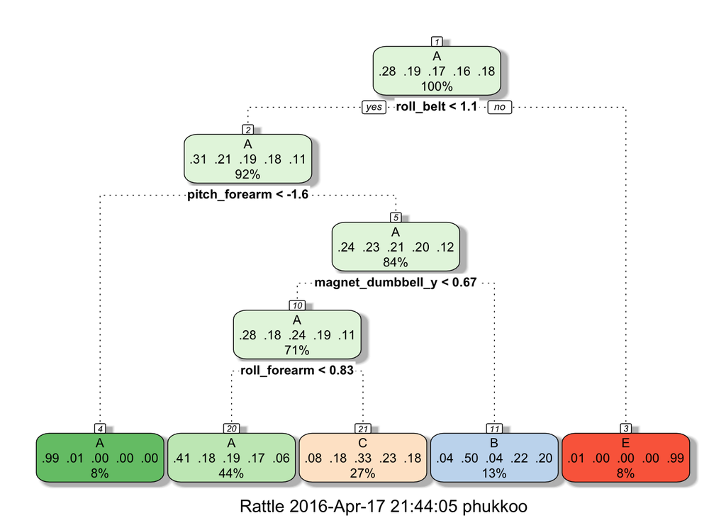

```r
# fancy tree respresentation of classification tree
fancyRpartPlot(rpart_fit$finalModel)
```

### Predicting using Classification Tree Model

```r
# predict outcomes using validation set
rpart_predict <- predict(rpart_fit, valid)
# Confusion matrix for Classification tree model
(rpart_conf <- confusionMatrix(valid$classe, rpart_predict))
```

```
## Confusion Matrix and Statistics
##
##           Reference
## Prediction    A    B    C    D    E
##          A 1544   21  107    0    2
##          B  492  391  256    0    0
##          C  474   38  514    0    0
##          D  436  175  353    0    0
##          E  155  138  293    0  496
##
## Overall Statistics
##
##                Accuracy : 0.5004
##                  95% CI : (0.4876, 0.5133)
##     No Information Rate : 0.5269
##     P-Value [Acc > NIR] : 1
##
##                   Kappa : 0.3464
##  Mcnemar's Test P-Value : NA
##
## Statistics by Class:
##
##                      Class: A Class: B Class: C Class: D Class: E
## Sensitivity            0.4979  0.51245  0.33749       NA  0.99598
## Specificity            0.9533  0.85396  0.88262   0.8362  0.89122
## Pos Pred Value         0.9223  0.34328  0.50097       NA  0.45841
## Neg Pred Value         0.6303  0.92162  0.79234       NA  0.99958
## Prevalence             0.5269  0.12965  0.25879   0.0000  0.08462
## Detection Rate         0.2624  0.06644  0.08734   0.0000  0.08428
## Detection Prevalence   0.2845  0.19354  0.17434   0.1638  0.18386
## Balanced Accuracy      0.7256  0.68321  0.61006       NA  0.94360
```

### Accuracy for Classification tree model

```r
(rpart_accuracy <- rpart_conf$overall[1])
```

```
##  Accuracy
## 0.5004248
```

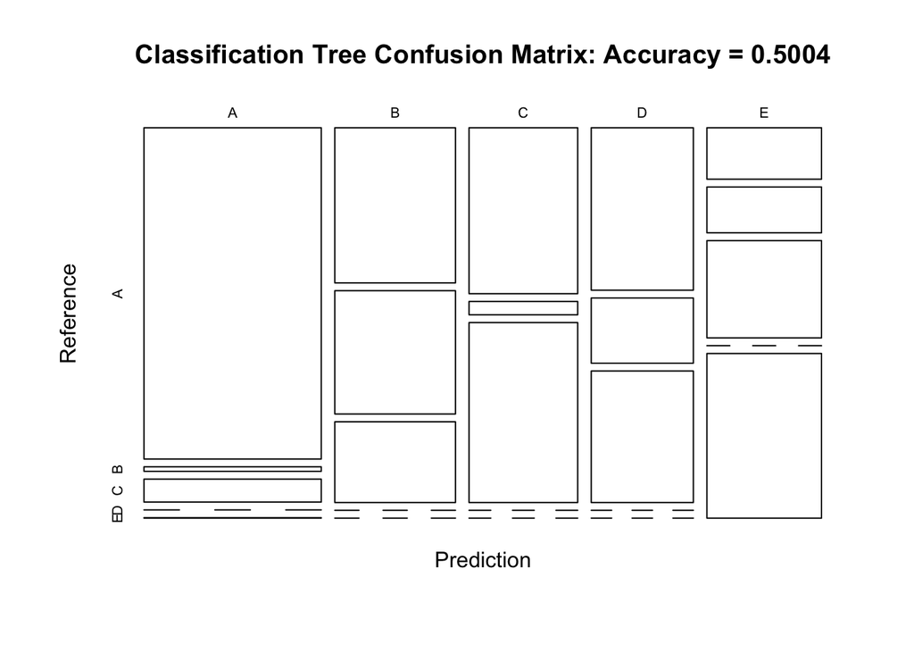

```r
# Plot of the accuracy for the various "classe" values
plot(rpart_conf$table, col = rpart_conf$byClass, main = paste("Classification Tree Confusion Matrix: Accuracy =",
round(rpart_conf$overall['Accuracy'], 4)))
```

## Model using Generalized Boosting Regression

```r
gbm_fit <- train(classe ~ ., data=train,
                method="gbm",
                preProcess=c("center", "scale"),
                trControl=fitControl,
                verbose=FALSE)
print(gbm_fit, digits = 4)
```

```
## Stochastic Gradient Boosting
##
## 13737 samples
##    52 predictor
##     5 classes: 'A', 'B', 'C', 'D', 'E'
##
## Pre-processing: centered (52), scaled (52)
## Resampling: Cross-Validated (5 fold)
## Summary of sample sizes: 10990, 10990, 10990, 10988, 10990
## Resampling results across tuning parameters:
##
##   interaction.depth  n.trees  Accuracy  Kappa   Accuracy SD  Kappa SD
##   1                   50      0.7504    0.6837  0.014896     0.018677
##   1                  100      0.8240    0.7772  0.009346     0.011813
##   1                  150      0.8551    0.8166  0.009610     0.012133
##   2                   50      0.8562    0.8177  0.006441     0.008159
##   2                  100      0.9070    0.8824  0.007763     0.009835
##   2                  150      0.9328    0.9150  0.007448     0.009435
##   3                   50      0.8950    0.8671  0.006476     0.008218
##   3                  100      0.9427    0.9275  0.007422     0.009403
##   3                  150      0.9593    0.9485  0.006938     0.008787
##
## Tuning parameter 'shrinkage' was held constant at a value of 0.1
##
## Tuning parameter 'n.minobsinnode' was held constant at a value of 10
## Accuracy was used to select the optimal model using  the largest value.
## The final values used for the model were n.trees = 150,
##  interaction.depth = 3, shrinkage = 0.1 and n.minobsinnode = 10.
```

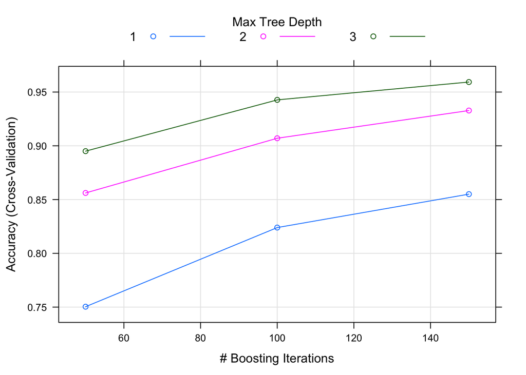

```r
# plot GBM
plot(gbm_fit)
```

### Predicting using GBM Model

```r
# predict outcomes using validation set
gbm_predict <- predict(gbm_fit, valid)
# Show prediction result
(gbm_conf <- confusionMatrix(valid$classe, gbm_predict))
```

```
## Confusion Matrix and Statistics
##
##           Reference
## Prediction    A    B    C    D    E
##          A 1643   17    8    5    1
##          B   33 1075   30    1    0
##          C    0   29  982   14    1
##          D    2    6   28  914   14
##          E    1    9   11   14 1047
##
## Overall Statistics
##
##                Accuracy : 0.9619
##                  95% CI : (0.9567, 0.9667)
##     No Information Rate : 0.2853
##     P-Value [Acc > NIR] : < 2.2e-16
##
##                   Kappa : 0.9519
##  Mcnemar's Test P-Value : 1.699e-05
##
## Statistics by Class:
##
##                      Class: A Class: B Class: C Class: D Class: E
## Sensitivity            0.9786   0.9463   0.9273   0.9641   0.9849
## Specificity            0.9926   0.9865   0.9909   0.9899   0.9927
## Pos Pred Value         0.9815   0.9438   0.9571   0.9481   0.9677
## Neg Pred Value         0.9915   0.9871   0.9842   0.9931   0.9967
## Prevalence             0.2853   0.1930   0.1799   0.1611   0.1806
## Detection Rate         0.2792   0.1827   0.1669   0.1553   0.1779
## Detection Prevalence   0.2845   0.1935   0.1743   0.1638   0.1839
## Balanced Accuracy      0.9856   0.9664   0.9591   0.9770   0.9888
```

### Accuracy of GBM model

```r
#GBM accuracy
(gbm_accuracy <- gbm_conf$overall[1])
```

```
##  Accuracy
## 0.9619371
```

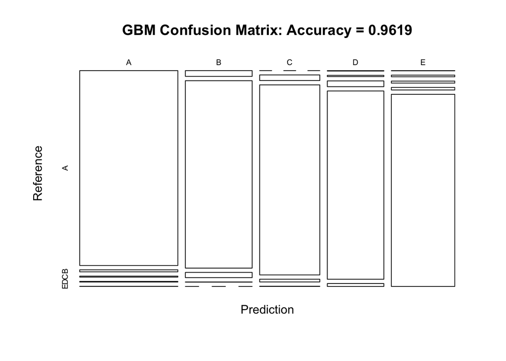

```r
plot(gbm_conf$table, col = gbm_conf$byClass, main = paste("GBM Confusion Matrix: Accuracy =", round(gbm_conf$overall['Accuracy'], 4)))
```

## Model using Random Forest

```r
# using Random Forest

rf_fit <- train(classe ~ ., data = train, method = "rf", preProcess=c("center", "scale"),
                trControl = fitControl)
print(rf_fit, digits = 4)
```

```
## Random Forest
##
## 13737 samples
##    52 predictor
##     5 classes: 'A', 'B', 'C', 'D', 'E'
##
## Pre-processing: centered (52), scaled (52)
## Resampling: Cross-Validated (5 fold)
## Summary of sample sizes: 10988, 10990, 10991, 10989, 10990
## Resampling results across tuning parameters:
##
##   mtry  Accuracy  Kappa   Accuracy SD  Kappa SD
##    2    0.9908    0.9884  0.001812     0.002294
##   27    0.9904    0.9878  0.002037     0.002577
##   52    0.9853    0.9814  0.002933     0.003711
##
## Accuracy was used to select the optimal model using  the largest value.
## The final value used for the model was mtry = 2.
```

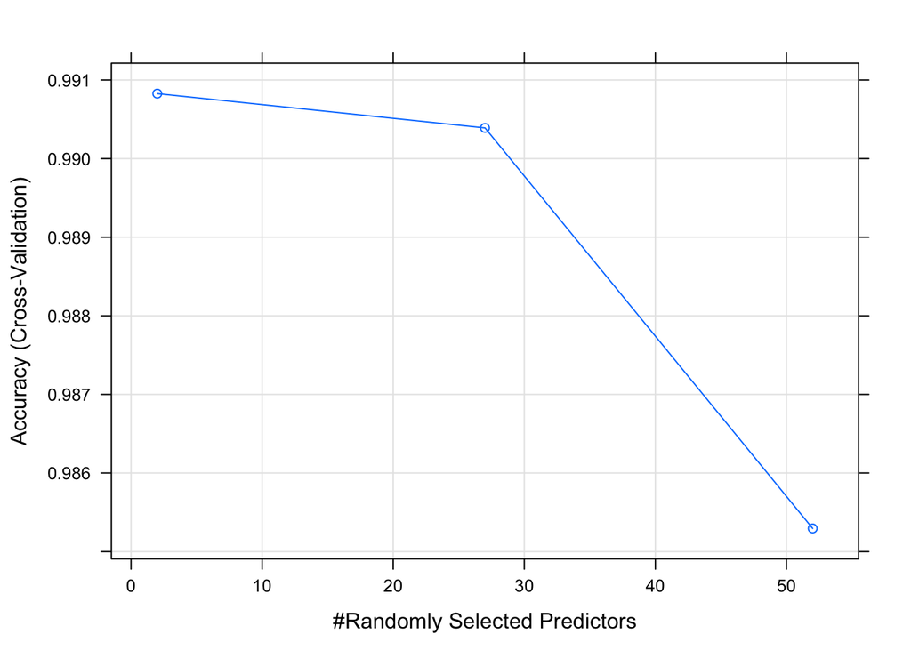

```r
#plot Random Forest
plot(rf_fit)
```

### Predicting using Random Forest Model

```r
# predict outcomes using validation set
rf_predict <- predict(rf_fit, valid)
# Show prediction result
(rf_conf <- confusionMatrix(valid$classe, rf_predict))
```

```
## Confusion Matrix and Statistics
##
##           Reference
## Prediction    A    B    C    D    E
##          A 1672    0    0    0    2
##          B    1 1136    2    0    0
##          C    0    3 1022    1    0
##          D    0    0   19  943    2
##          E    0    0    0    2 1080
##
## Overall Statistics
##
##                Accuracy : 0.9946
##                  95% CI : (0.9923, 0.9963)
##     No Information Rate : 0.2843
##     P-Value [Acc > NIR] : < 2.2e-16
##
##                   Kappa : 0.9931
##  Mcnemar's Test P-Value : NA
##
## Statistics by Class:
##
##                      Class: A Class: B Class: C Class: D Class: E
## Sensitivity            0.9994   0.9974   0.9799   0.9968   0.9963
## Specificity            0.9995   0.9994   0.9992   0.9957   0.9996
## Pos Pred Value         0.9988   0.9974   0.9961   0.9782   0.9982
## Neg Pred Value         0.9998   0.9994   0.9957   0.9994   0.9992
## Prevalence             0.2843   0.1935   0.1772   0.1607   0.1842
## Detection Rate         0.2841   0.1930   0.1737   0.1602   0.1835
## Detection Prevalence   0.2845   0.1935   0.1743   0.1638   0.1839
## Balanced Accuracy      0.9995   0.9984   0.9895   0.9963   0.9979
```

### Accuracy of Random Forest Model

```r
#  RF accuracy
(rf_accuracy <- rf_conf$overall[1])
```

```
##  Accuracy
## 0.9945624
```

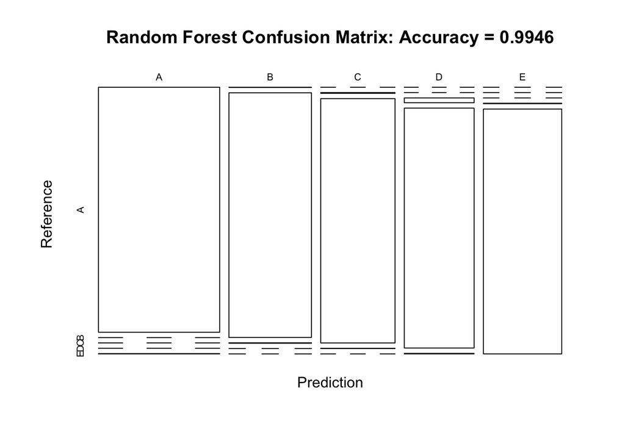

```r
plot(rf_conf$table, col = rf_conf$byClass, main = paste("Random Forest Confusion Matrix: Accuracy =", round(rf_conf$overall['Accuracy'], 4)))
```

## Prediction on Testing Set

We now use random forests to predict the outcome variable classe for the testing set, since had the highest accuracy of 0.99 compared to GBM Model ( accuracy = 0.96 )and Classification Tree Model (accuracy 0.5)

```r
(predict(rf_fit, testData))
```

```
##  [1] B A B A A E D B A A B C B A E E A B B B
## Levels: A B C D E
```